# Machine Learning Engineer Nanodegree (Udacity) - Capstone Project

# Project Overview

- OCR is a field of research in pattern recognition, artificial intelligence and computer vision.
- The field of optical character recognition (OCR) is very important, especially for offline handwritten recognition systems. Offline handwritten recognition systems are different from online handwritten recognition systems. The ability to deal with large amounts of script data in certain contexts will be invaluable. One example of these applications is the automation of the text transcription process applied on ancient documents considering the complex and irregular nature of writing. Arabic optical text recognition is experiencing slow development compared to other languages.
- Handwritten Arabic character recognition (HACR) has attracted considerable attention in recent decades. Researchers have made significant breakthroughs in this field with the rapid development of deep learning algorithms. Arabic is a kind of the Semitic language used in countries of the Middle East as a mother language of millions people.
- Arabic handwriting fonts is an ancient art, and there are a lot of old books and scripts need to digitize. That what motivate researchers to build algorithms for this job to save ancient Arabic culture, through this link described the alphabet of the arabic language:
  - https://en.wikipedia.org/wiki/Arabic_alphabet

# Problem Statement

- Generally, the Arabic alphabet characters consist of **twenty-eight** alphabet characters.
- There is also a big variety of Arabic handwriting fonts, Arabs still use till now. Most of Arab people write Arabic with two special techniques which are **Naskh** and **Reqaa** and sometimes by mistake and fast writing they write a mix of both. Also Some characters are very confusable with similar character stroke.
- so the important role for machine learning comes now, and specially the **Classification Algorithms** or **Deep Learning**, which will help us to solve this problem. This problem belongs to the supervised learning.

# Datasets

- The following link from kaggle, contains the dataset for this project: https://www.kaggle.com/mloey1/ahcd1
- According to the description of the dataset, here are more info about it:
  - The dataset is composed of 16,800 characters written by 60 participants, the age range is between 19 to 40 years, and 90% of participants are right-hand. Each participant wrote each character (from ’alef’ to ’yaa’) ten times.
  - The database is partitioned into two sets: a training set (13,440 characters to 480 images per class) and a test set (3,360 characters to 120 images per class), and writers of training set and test set are exclusive.
  - Ordering of including writers to test set are randomized to make sure that writers of test set are not from a single institution (to ensure variability of the test set).

# Metrics

- According to the dataset description in the previous link, “test set is randomized, shuffled and has a good variability.” So I will use accuracy score on test set to evaluate the classifier.

# Some important libraries

```python
import numpy as np
import pandas as pd
import matplotlib.pyplot as plt
%matplotlib inline
```

# Loading the datasets

```python
image_train = pd.read_csv("csvTrainImages 13440x1024.csv", header=None)
label_train = pd.read_csv("csvTrainLabel 13440x1.csv"    , header=None)
image_test  = pd.read_csv("csvTestImages 3360x1024.csv"  , header=None)
label_test  = pd.read_csv("csvTestLabel 3360x1.csv"      , header=None)
```

# Data Exploration

```python
print(image_train.shape)
print(image_test.shape)
print(label_train.shape)
print(label_test.shape)
```

```
(13440, 1024)
(3360, 1024)
(13440, 1)
(3360, 1)
```

```python
display(image_train.head())
```

|  | 0 | 1 | 2 | 3 | 4 | 5 | 6 | 7 | 8 | 9 | ... | 1014 | 1015 | 1016 | 1017 | 1018 | 1019 | 1020 | 1021 | 1022 | 1023 |
| --- | --- | --- | --- | --- | --- | --- | --- | --- | --- | --- | --- | --- | --- | --- | --- | --- | --- | --- | --- | --- | --- |
| 0 | 0 | 0 | 0 | 0 | 0 | 0 | 0 | 0 | 0 | 0 | ... | 0 | 0 | 0 | 0 | 0 | 0 | 0 | 0 | 0 | 0 |
| 1 | 0 | 0 | 0 | 0 | 0 | 0 | 0 | 0 | 0 | 0 | ... | 0 | 0 | 0 | 0 | 0 | 0 | 0 | 0 | 0 | 0 |
| 2 | 0 | 0 | 0 | 0 | 0 | 0 | 0 | 0 | 0 | 0 | ... | 0 | 0 | 0 | 0 | 0 | 0 | 0 | 0 | 0 | 0 |
| 3 | 0 | 0 | 0 | 0 | 0 | 0 | 0 | 0 | 0 | 0 | ... | 0 | 0 | 0 | 0 | 0 | 0 | 0 | 0 | 0 | 0 |
| 4 | 0 | 0 | 0 | 0 | 0 | 0 | 0 | 0 | 0 | 0 | ... | 0 | 0 | 0 | 0 | 0 | 0 | 0 | 0 | 0 | 0 |

5 rows × 1024 columns

```python
print('max = ', np.max(image_train.max()),"\t"," min = ", np.min(image_train.min()))
```

```
max =  255 	  min =  0
```

```python
display(label_train.head())
```

|  | 0 |
| --- | --- |
| 0 | 1 |
| 1 | 1 |
| 2 | 1 |
| 3 | 1 |
| 4 | 1 |

```python
label_train.describe()
```

|  | 0 |
| --- | --- |
| count | 13440.000000 |
| mean | 14.500000 |
| std | 8.078048 |
| min | 1.000000 |
| 25% | 7.750000 |
| 50% | 14.500000 |
| 75% | 21.250000 |
| max | 28.000000 |

```python
x_train = image_train.values
y_train = np.array(label_train[0])
x_test = image_test.values
y_test = np.array(label_test[0])
```

```python
print(x_train.shape)
print(y_train.shape)
print(x_test.shape)
print(y_test.shape)
```

```
(13440, 1024)
(13440,)
(3360, 1024)
(3360,)
```

# Exploratory Visualization

- Here is the arabic labels and the the arabic letters.

```python
arabic_labels = ['alef', 'baa', 'taa', 'thaa', 'jeem', 'haa', 'khaa', 'dal', 'thal',
                'raa', 'zay', 'seen', 'sheen', 'sad', 'dad', 'ttaa', 'zaa', 'ain',
                'ghain', 'faa', 'qaf', 'kaf', 'lam', 'meem', 'noon', 'haa', 'waw', 'yaa']
arabic_letters = ['أ', 'ب', 'ت', 'ث', 'ج', 'ح', 'خ', 'د', 'ذ',
                'ر', 'ز', 'س', 'ش', 'ص', 'ض', 'ط', 'ظ', 'ع',
                'غ', 'ف', 'ق', 'ك', 'ل', 'م', 'ن', 'هـ', 'و', 'ي']
```

# Some visualizing for a 20 training images of arabic letters

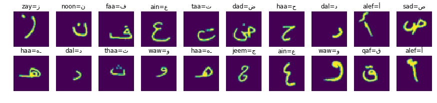

```python
random_array = np.random.randint(x_train.shape[0], size=(2,10))
plt.figure(figsize=[15,3])
for i in range(10):
    plt.subplot(2,10,i+1)
    a = int(y_train[random_array[0,i]]-1)
    plt.title(arabic_labels[a] + '=' + arabic_letters[a])
    plt.imshow(x_train[random_array[0,i]].reshape(32,32).squeeze().T)
    plt.axis('off')
    plt.subplot(2,10,i+11)
    b = int(y_train[random_array[1,i]]-1)
    plt.title(arabic_labels[b] + '=' + arabic_letters[b])
    plt.imshow(x_train[random_array[1,i]].reshape(32,32).squeeze().T)
    plt.axis('off')
```

# Showing a single image in more details

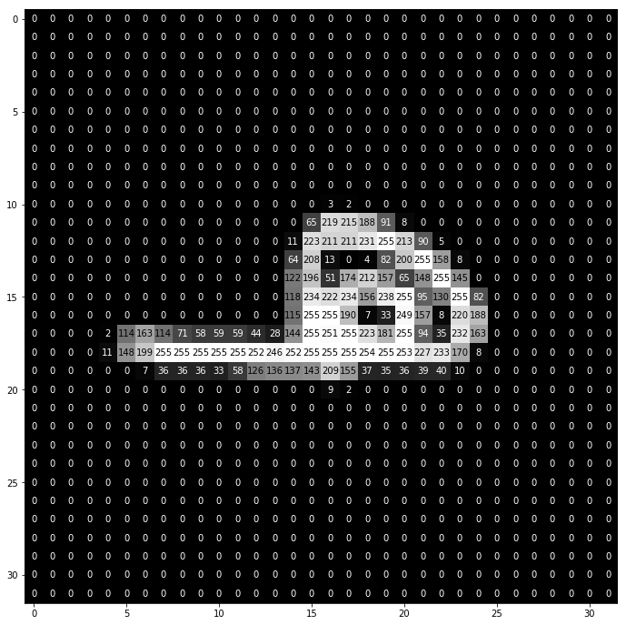

```python
def visualize_input(img, ax):
    ax.imshow(img, cmap='gray')
    width, height = img.shape
    thresh = img.max()/2.5
    for x in range(width):
        for y in range(height):
            ax.annotate(str(round(img[x][y],2)), xy=(y,x),
                        horizontalalignment='center',
                        verticalalignment='center',
                        color='white' if img[x][y]<thresh else 'black')
fig = plt.figure(figsize = (12,12))
ax = fig.add_subplot(111)
sample_img = x_train[random_array[1,0]]
visualize_input(sample_img.reshape(32,32).squeeze().T, ax)
```

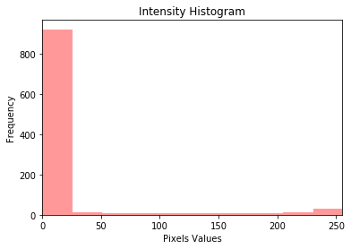

```python
plt.xlim((0,255))
plt.hist(sample_img, range=(0,256), color='red', alpha=0.4)
plt.xlabel('Pixels Values')
plt.ylabel('Frequency')
plt.title('Intensity Histogram')
plt.show()
```

# Data Preprocessing

### Rescaling the Images by dividing each pixel in each image by 255

```python
x_train = image_train.values/255.0
x_test = image_test.values/255.0
```

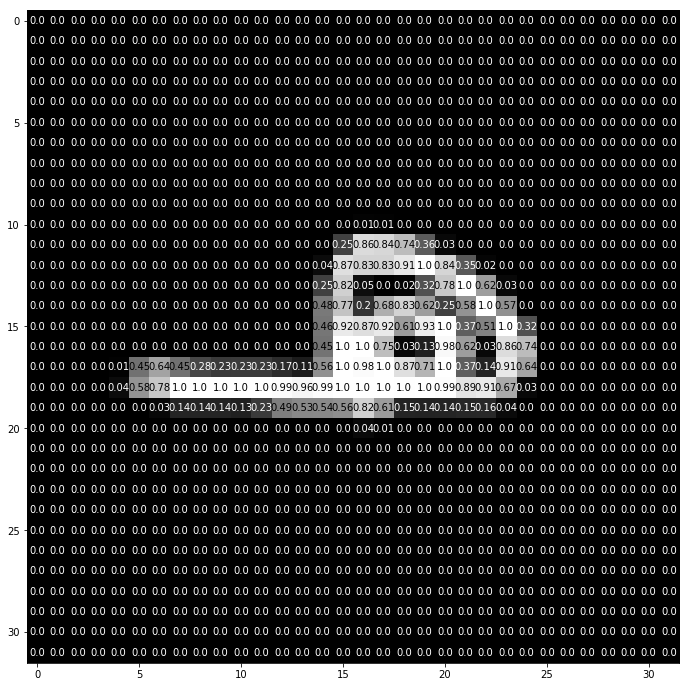

```python
fig = plt.figure(figsize = (12,12))
ax = fig.add_subplot(111)
sample_img = x_train[random_array[1,0]]
visualize_input(sample_img.reshape(32,32).squeeze().T, ax)
```

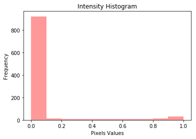

```python
plt.hist(sample_img, color='red', alpha=0.4)
plt.xlabel('Pixels Values')
plt.ylabel('Frequency')
plt.title('Intensity Histogram')
plt.show()
```

# Normalizing the images

```python
from sklearn.preprocessing import normalize
x_train = normalize(x_train)
x_test = normalize(x_test)
```

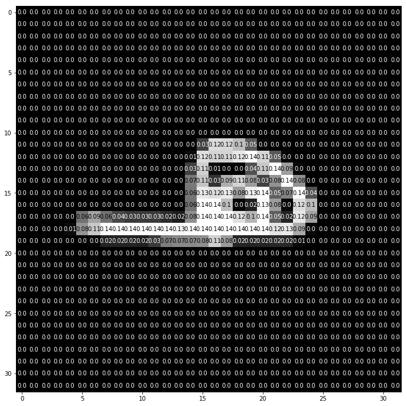

```python
fig = plt.figure(figsize = (12,12))
ax = fig.add_subplot(111)
sample_img = x_train[random_array[1,0]]
visualize_input(sample_img.reshape(32,32).squeeze().T, ax)
```

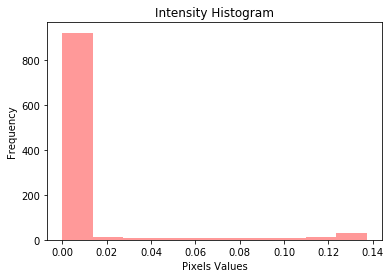

```python
plt.hist(sample_img, color='red', alpha=0.4)
plt.xlabel('Pixels Values')
plt.ylabel('Frequency')
plt.title('Intensity Histogram')
plt.show()
```

# Dimensionality Reduction

### the dimensionality reduction will be applied is Principle Component Analysis “PCA”.

```python
n_components = 60
from sklearn.decomposition import PCA
pca = PCA(n_components=n_components, svd_solver='randomized', whiten=True).fit(x_train)
x_train_pca = pca.transform(x_train)
x_test_pca = pca.transform(x_test)
```

# The implementation of the classifiers

## Implementation (Part 1) - Supervised Learning Algorithms.

### Firstly, the accuracy score will be used to evaluate the classifier.

```python
from sklearn.metrics import accuracy_score
def get_accuracy (clf, xtrain, ytrain, xtest, ytest):
    clf.fit(xtrain, ytrain)
    pred = clf.predict(xtest)
    acc = accuracy_score(ytest, pred)*100
    print('Test accuracy: %.4f%%' % acc)
    return acc
```

```python
# Empty dictionary to save accuracy values
accuracy_values = {}
```

# First Classifier: Support Vector Classifier (SVC)

### Through the implementation of the SVC, the grid search is used tune its hyper-parameters.

```python
# Train a SVM classification model
from sklearn.svm import SVC
from sklearn.model_selection import GridSearchCV
print("Fitting the classifier to the training set")
param_grid = {'C': [1e3, 5e3, 1e4, 5e4, 1e5],
              'gamma': [0.0001, 0.0005, 0.001, 0.005, 0.01, 0.1], }
clf = GridSearchCV(SVC(kernel='rbf', class_weight='balanced', random_state=42), param_grid, n_jobs=4, verbose=1 )
clf = clf.fit(x_train_pca, y_train)
print("Best estimator found by grid search:")
print(clf.best_estimator_)
```

```
Fitting the classifier to the training set
Fitting 3 folds for each of 30 candidates, totalling 90 fits
```

```
[Parallel(n_jobs=4)]: Done  42 tasks      | elapsed:  7.8min
[Parallel(n_jobs=4)]: Done  90 out of  90 | elapsed: 17.7min finished
```

```
Best estimator found by grid search:
SVC(C=1000.0, cache_size=200, class_weight='balanced', coef0=0.0,
  decision_function_shape='ovr', degree=3, gamma=0.01, kernel='rbf',
  max_iter=-1, probability=False, random_state=42, shrinking=True,
  tol=0.001, verbose=False)
```

### The accuracy score of the SVC

```python
from sklearn.svm import SVC
clf_svc = SVC(C=1000.0, cache_size=200, class_weight='balanced', coef0=0.0,
  decision_function_shape='ovr', degree=3, gamma=0.01, kernel='rbf',
  max_iter=-1, probability=False, random_state=42, shrinking=True,
  tol=0.001, verbose=False)
accuracy_values['SVM'] = get_accuracy(clf_svc,x_train_pca, y_train, x_test_pca, y_test)
```

```
Test accuracy: 74.2262%
```

# Second Classifier: Random Forest

### Through the implementation of the Random Forest, the grid search is used tune its hyper-parameters.

```python
from sklearn.ensemble import RandomForestClassifier
from sklearn.model_selection import GridSearchCV
print("Fitting the classifier to the training set")
param_grid = {'n_estimators':list(range(10,40,2)),
              'max_depth':list(range(3,30)), }
clf = GridSearchCV(RandomForestClassifier(random_state=42), param_grid, n_jobs=4, verbose=1)
clf = clf.fit(x_train_pca, y_train)
print("Best estimator found by grid search:")
print(clf.best_estimator_)
```

```
Fitting the classifier to the training set
Fitting 3 folds for each of 405 candidates, totalling 1215 fits
```

```
[Parallel(n_jobs=4)]: Done  42 tasks      | elapsed:    9.4s
[Parallel(n_jobs=4)]: Done 192 tasks      | elapsed:  1.0min
[Parallel(n_jobs=4)]: Done 442 tasks      | elapsed:  3.5min
[Parallel(n_jobs=4)]: Done 792 tasks      | elapsed:  8.3min
[Parallel(n_jobs=4)]: Done 1215 out of 1215 | elapsed: 14.9min finished
```

```
Best estimator found by grid search:
RandomForestClassifier(bootstrap=True, class_weight=None, criterion='gini',
            max_depth=17, max_features='auto', max_leaf_nodes=None,
            min_impurity_decrease=0.0, min_impurity_split=None,
            min_samples_leaf=1, min_samples_split=2,
            min_weight_fraction_leaf=0.0, n_estimators=38, n_jobs=1,
            oob_score=False, random_state=42, verbose=0, warm_start=False)
```

### The accuracy score of the Random Forest

```python
from sklearn.ensemble import RandomForestClassifier
clf_R_forest = RandomForestClassifier(bootstrap=True, class_weight=None, criterion='gini',
            max_depth=17, max_features='auto', max_leaf_nodes=None,
            min_impurity_decrease=0.0, min_impurity_split=None,
            min_samples_leaf=1, min_samples_split=2,
            min_weight_fraction_leaf=0.0, n_estimators=38, n_jobs=1,
            oob_score=False, random_state=42, verbose=0, warm_start=False)
accuracy_values['Random Forest'] = get_accuracy(clf_R_forest,x_train_pca, y_train, x_test_pca, y_test)
```

```
Test accuracy: 53.3333%
```

# Third Classifier: AdaBoost

### Through the implementation of the AdaBoost, the grid search is used tune its hyper-parameters.

```python
from sklearn.ensemble import AdaBoostClassifier
from sklearn.model_selection import GridSearchCV
print("Fitting the classifier to the training set")
param_grid = {'n_estimators':list(range(10,40,2)), }
clf = GridSearchCV(AdaBoostClassifier(random_state=42), param_grid, n_jobs=4, verbose=1)
clf = clf.fit(x_train_pca, y_train)
print("Best estimator found by grid search:")
print(clf.best_estimator_)
```

```
Fitting the classifier to the training set
Fitting 3 folds for each of 15 candidates, totalling 45 fits
```

```
[Parallel(n_jobs=4)]: Done  45 out of  45 | elapsed:   50.5s finished
```

```
Best estimator found by grid search:
AdaBoostClassifier(algorithm='SAMME.R', base_estimator=None,
          learning_rate=1.0, n_estimators=34, random_state=42)
```

### The accuracy score of the AdaBoost

```python
from sklearn.ensemble import AdaBoostClassifier
clf_ada = AdaBoostClassifier(algorithm='SAMME.R', base_estimator=None,
          learning_rate=1.0, n_estimators=34, random_state=42)
accuracy_values['AdaBoost'] = get_accuracy(clf_ada,x_train_pca, y_train, x_test_pca, y_test)
```

```
Test accuracy: 15.7440%
```

# Fourth Classifier: Decision Tree

### Through the implementation of the Decision Tree, the grid search is used tune its hyper-parameters.

```python
from sklearn.tree import DecisionTreeClassifier
from sklearn.model_selection import GridSearchCV
print("Fitting the classifier to the training set")
param_grid = {'max_depth':list(range(3,30)), }
clf = GridSearchCV(DecisionTreeClassifier(random_state=42), param_grid, n_jobs=3, verbose=1)
clf = clf.fit(x_train_pca, y_train)
print("Best estimator found by grid search:")
print(clf.best_estimator_)
```

```
Fitting the classifier to the training set
Fitting 3 folds for each of 27 candidates, totalling 81 fits
```

```
[Parallel(n_jobs=3)]: Done  44 tasks      | elapsed:   14.7s
[Parallel(n_jobs=3)]: Done  81 out of  81 | elapsed:   32.1s finished
```

```
Best estimator found by grid search:
DecisionTreeClassifier(class_weight=None, criterion='gini', max_depth=28,
            max_features=None, max_leaf_nodes=None,
            min_impurity_decrease=0.0, min_impurity_split=None,
            min_samples_leaf=1, min_samples_split=2,
            min_weight_fraction_leaf=0.0, presort=False, random_state=42,
            splitter='best')
```

### The accuracy score of the Decision Tree

```python
from sklearn.tree import DecisionTreeClassifier
clf_dtree = DecisionTreeClassifier(class_weight=None, criterion='gini', max_depth=28,
            max_features=None, max_leaf_nodes=None,
            min_impurity_decrease=0.0, min_impurity_split=None,
            min_samples_leaf=1, min_samples_split=2,
            min_weight_fraction_leaf=0.0, presort=False, random_state=42,
            splitter='best')
accuracy_values['Decision Tree'] = get_accuracy(clf_dtree,x_train_pca, y_train, x_test_pca, y_test)
```

```
Test accuracy: 32.6190%
```

## Implementation (Part 2) - Deep Learning Algorithms.

```python
from keras.utils import np_utils
# one-hot encode the labels
y_train_encoded = np_utils.to_categorical(y_train-1, num_classes=28)
y_test_encoded = np_utils.to_categorical(y_test-1, num_classes=28)
```

```python
y_train_encoded.shape
```

```
(13440, 28)
```

```python
y_train_encoded[0]
```

```
array([ 1.,  0.,  0.,  0.,  0.,  0.,  0.,  0.,  0.,  0.,  0.,  0.,  0.,
        0.,  0.,  0.,  0.,  0.,  0.,  0.,  0.,  0.,  0.,  0.,  0.,  0.,
        0.,  0.])
```

### Arabic letters are reshaped to a size of 32x32

```python
x_train_reshape = x_train.reshape(x_train.shape[0], 32, 32)
x_test_reshape = x_test.reshape(x_test.shape[0], 32, 32)
```

```python
print(x_train_reshape[0].shape)
x_train_reshape[0]
```

```
(32, 32)
```

```
array([[ 0.,  0.,  0., ...,  0.,  0.,  0.],
       [ 0.,  0.,  0., ...,  0.,  0.,  0.],
       [ 0.,  0.,  0., ...,  0.,  0.,  0.],
       ...,
       [ 0.,  0.,  0., ...,  0.,  0.,  0.],
       [ 0.,  0.,  0., ...,  0.,  0.,  0.],
       [ 0.,  0.,  0., ...,  0.,  0.,  0.]])
```

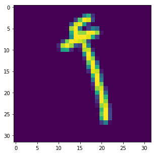

```python
plt.figure(figsize=(5,5))
plt.imshow(x_train_reshape[0].squeeze().T)
```

# First Model:

# The Multilayer Perceptron Model (MLP) - the model architecture.

```python
from keras.models import Sequential
from keras.layers import Dense, Dropout, Flatten

# define the model
model = Sequential()
model.add(Flatten(input_shape=x_train_reshape.shape[1:]))
model.add(Dense(128, activation='relu'))
model.add(Dropout(0.2))
model.add(Dense(64, activation='relu'))
model.add(Dropout(0.2))
model.add(Dense(28, activation='softmax'))

# summarize the model
model.summary()
```

```
_________________________________________________________________
Layer (type)                 Output Shape              Param #
=================================================================
flatten_1 (Flatten)          (None, 1024)              0
_________________________________________________________________
dense_1 (Dense)              (None, 128)               131200
_________________________________________________________________
dropout_1 (Dropout)          (None, 128)               0
_________________________________________________________________
dense_2 (Dense)              (None, 64)                8256
_________________________________________________________________
dropout_2 (Dropout)          (None, 64)                0
_________________________________________________________________
dense_3 (Dense)              (None, 28)                1820
=================================================================
Total params: 141,276
Trainable params: 141,276
Non-trainable params: 0
_________________________________________________________________
```

## Compiling the model:

```python
# compile the model
model.compile(loss='categorical_crossentropy', optimizer='Nadam', metrics=['accuracy'])
```

## Calculating the classification accuracy on the test set before training.

```python
# evaluate test accuracy
score = model.evaluate(x_test_reshape, y_test_encoded, verbose=0)
accuracy = 100*score[1]

# print test accuracy
print('Test accuracy: %.4f%%' % accuracy)
```

```
Test accuracy: 4.0179%
```

## Train the model:

```python
from keras.callbacks import ModelCheckpoint

# train the model
checkpointer = ModelCheckpoint(filepath='HACR.model.best.hdf5',
                               verbose=1, save_best_only=True)
hist = model.fit(x_train_reshape, y_train_encoded, batch_size=128, epochs=60,
          validation_split=0.2, callbacks=[checkpointer],
          verbose=1, shuffle=True)
```

```
Train on 10752 samples, validate on 2688 samples
```

## Load the model with the best classification accuracy on the validation set:

```python
# load the weights that yielded the best validation accuracy
model.load_weights('HACR.model.best.hdf5')
```

## Calculating the classification accuracy on the test set:

```python
# evaluate test accuracy
score = model.evaluate(x_test_reshape, y_test_encoded, verbose=0)
accuracy = 100*score[1]
accuracy_values['MLP'] = accuracy
# print test accuracy
print('Test accuracy: %.4f%%' % accuracy)
```

```
Test accuracy: 71.1012%
```

# Second Model:

# Convolutional Neural Network Model (CNN).

```python
from keras.models import Sequential
from keras.layers import Dense, Dropout, Flatten
from keras.layers import BatchNormalization
from keras.layers import Conv1D, MaxPooling1D

# define the model
cnn_model = Sequential()
cnn_model.add(Conv1D(filters=128, kernel_size=3, padding='valid', activation='relu', input_shape=(32, 32)))
cnn_model.add(MaxPooling1D(pool_size=2))
cnn_model.add(BatchNormalization())
cnn_model.add(Dropout(0.5))
cnn_model.add(Conv1D(filters=64, kernel_size=3, padding='same', activation='relu',))
cnn_model.add(MaxPooling1D(pool_size=2))
cnn_model.add(BatchNormalization())
#cnn_model.add(Dropout(0.3))
cnn_model.add(Flatten())
cnn_model.add(Dense(128, activation='relu'))
cnn_model.add(Dropout(0.2))
cnn_model.add(BatchNormalization())
cnn_model.add(Dense(64, activation='relu'))
cnn_model.add(Dropout(0.2))
cnn_model.add(Dense(28, activation='softmax'))

# summarize the model
cnn_model.summary()
```

```
_________________________________________________________________
Layer (type)                 Output Shape              Param #
=================================================================
conv1d_1 (Conv1D)            (None, 30, 128)           12416
_________________________________________________________________
max_pooling1d_1 (MaxPooling1 (None, 15, 128)           0
_________________________________________________________________
batch_normalization_1 (Batch (None, 15, 128)           512
_________________________________________________________________
dropout_3 (Dropout)          (None, 15, 128)           0
_________________________________________________________________
conv1d_2 (Conv1D)            (None, 15, 64)            24640
_________________________________________________________________
max_pooling1d_2 (MaxPooling1 (None, 7, 64)             0
_________________________________________________________________
batch_normalization_2 (Batch (None, 7, 64)             256
_________________________________________________________________
flatten_2 (Flatten)          (None, 448)               0
_________________________________________________________________
dense_4 (Dense)              (None, 128)               57472
_________________________________________________________________
dropout_4 (Dropout)          (None, 128)               0
_________________________________________________________________
batch_normalization_3 (Batch (None, 128)               512
_________________________________________________________________
dense_5 (Dense)              (None, 64)                8256
_________________________________________________________________
dropout_5 (Dropout)          (None, 64)                0
_________________________________________________________________
dense_6 (Dense)              (None, 28)                1820
=================================================================
Total params: 105,884
Trainable params: 105,244
Non-trainable params: 640
_________________________________________________________________
```

## Compiling the model:

```python
# compile the model
cnn_model.compile(loss='categorical_crossentropy', optimizer='Nadam', metrics=['accuracy'])
```

## Train the model:

```python
from keras.callbacks import ModelCheckpoint

# train the model
checkpointer = ModelCheckpoint(filepath='HACR_CNN.cnn_model.best.hdf5',
                               verbose=1, save_best_only=True)
hist = cnn_model.fit(x_train_reshape, y_train_encoded, batch_size=128, epochs=30,
                     validation_split=0.2, callbacks=[checkpointer], verbose=1, shuffle=True)
```

```
Train on 10752 samples, validate on 2688 samples
```

## Load the model with the best classification accuracy on the validation set:

```python
# load the weights that yielded the best validation accuracy
cnn_model.load_weights('HACR_CNN.cnn_model.best.hdf5')
```

## Calculating the classification accuracy on the test set:

```python
# evaluate test accuracy
score = cnn_model.evaluate(x_test_reshape, y_test_encoded, verbose=0)
accuracy = 100*score[1]
accuracy_values['CNN'] = accuracy
# print test accuracy
print('Test accuracy: %.4f%%' % accuracy)
```

```
Test accuracy: 86.0714%
```

# Comparing Different Classification Algorithms Results:

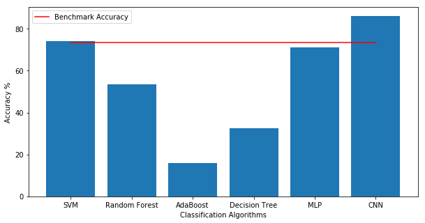

```python
plt.figure(figsize=(10, 5))
x = list(range(6))
y = np.ones(6)*73.4
plt.plot(x, y, color='r', label="Benchmark Accuracy")
plt.legend()
plt.bar(x, accuracy_values.values())
plt.xticks(x, accuracy_values.keys())
plt.xlabel('Classification Algorithms')
plt.ylabel('Accuracy %')
plt.show()
```

# Model Evaluation

## Confusion On test set:

```python
y_test_pred = np.argmax(cnn_model.predict(x_test_reshape), axis=1)
confusion = np.array([y_test != y_test_pred+1]).reshape(y_test.shape)
print('There are', confusion.sum(),'confusion sample')
confusion_df = pd.DataFrame()
confusion_df['true_label'] = [arabic_labels[i-1] for i in y_test[confusion]]
confusion_df['pred_label'] = [arabic_labels[i] for i in y_test_pred[confusion]]
confusion_df['true_letter'] = [arabic_letters[i-1] for i in y_test[confusion]]
confusion_df['pred_letter'] = [arabic_letters[i] for i in y_test_pred[confusion]]
from IPython.display import display
display(confusion_df.set_index('true_label'))
```

```
There are 468 confusion sample
```

| true_label | pred_label | true_letter | pred_letter |
| --- | --- | --- | --- |
| taa | thaa | ت | ث |
| jeem | khaa | ج | خ |
| raa | zay | ر | ز |
| qaf | sheen | ق | ش |
| taa | yaa | ت | ي |
| thaa | qaf | ث | ق |
| jeem | haa | ج | ح |
| khaa | haa | خ | ح |
| khaa | haa | خ | ح |
| ttaa | zaa | ط | ظ |
| dal | zay | د | ز |
| thal | zay | ذ | ز |
| zay | raa | ز | ر |
| ttaa | zaa | ط | ظ |
| qaf | yaa | ق | ي |
| lam | kaf | ل | ك |
| noon | thaa | ن | ث |
| alef | khaa | أ | خ |
| taa | thaa | ت | ث |
| taa | thaa | ت | ث |
| ain | thaa | ع | ث |
| faa | qaf | ف | ق |
| faa | qaf | ف | ق |
| qaf | seen | ق | س |
| lam | dal | ل | د |
| noon | thaa | ن | ث |
| taa | thaa | ت | ث |
| jeem | haa | ج | ح |
| haa | jeem | ح | ج |
| haa | khaa | ح | خ |
| ... | ... | ... | ... |
| jeem | yaa | ج | ي |
| jeem | haa | ج | ح |
| zay | raa | ز | ر |
| ain | ghain | ع | غ |
| faa | sheen | ف | ش |
| faa | qaf | ف | ق |
| noon | zay | ن | ز |
| haa | zaa | هـ | ظ |
| taa | thaa | ت | ث |
| taa | thaa | ت | ث |
| thaa | noon | ث | ن |
| thaa | taa | ث | ت |
| jeem | haa | ج | ح |
| khaa | haa | خ | ح |
| zay | raa | ز | ر |
| seen | sad | س | ص |
| ttaa | zaa | ط | ظ |
| ain | ghain | ع | غ |
| ain | khaa | ع | خ |
| yaa | seen | ي | س |
| yaa | seen | ي | س |
| jeem | haa | ج | ح |
| thal | dal | ذ | د |
| dad | sad | ض | ص |
| ain | ghain | ع | غ |
| ain | ghain | ع | غ |
| ghain | khaa | غ | خ |
| faa | haa | ف | هـ |
| noon | taa | ن | ت |
| noon | yaa | ن | ي |

468 rows × 3 columns

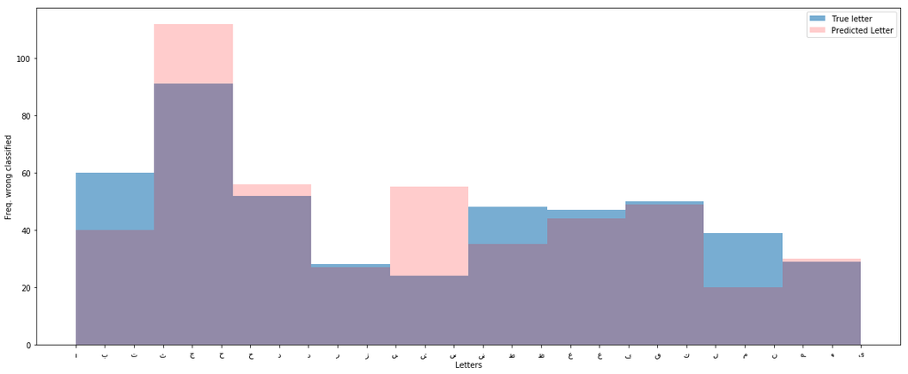

```python
plt.figure(figsize=(20, 8))
plt.hist(confusion_df['true_letter'], alpha=0.6, label= "True letter")
plt.hist(confusion_df['pred_letter'], color='r', alpha=0.2, label='Predicted Letter')
plt.legend()
plt.xlabel('Letters')
plt.ylabel('Freq. wrong classified')
plt.show()
```

## Confusion Visualization:

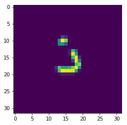

```
This image predicted as letter  thal  =  ذ
And that is right
```

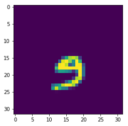

```
This image predicted as letter  waw  =  و
And that is right
```

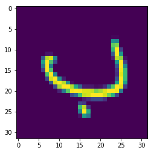

```
This image predicted as letter  baa  =  ب
And that is right
```

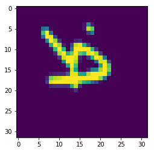

```
This image predicted as letter  zaa  =  ظ
And that is right
```

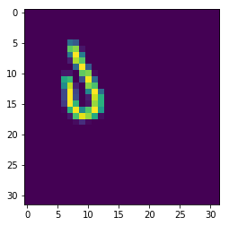

```
This image predicted as letter  alef  =  أ
But sorry that is wrong
```

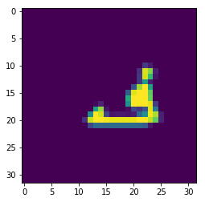

```
This image predicted as letter  qaf  =  ق
But sorry that is wrong
```

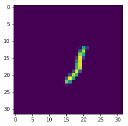

```
This image predicted as letter  raa  =  ر
And that is right
```

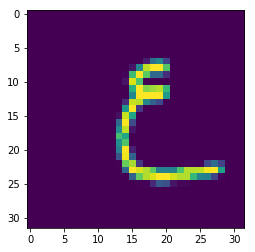

```
This image predicted as letter  ain  =  ع
And that is right
```

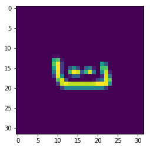

```
This image predicted as letter  taa  =  ت
And that is right
```

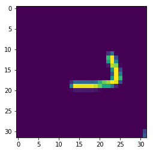

```
This image predicted as letter  dal  =  د
And that is right
```

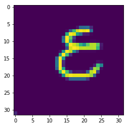

```
This image predicted as letter  ain  =  ع
And that is right
```

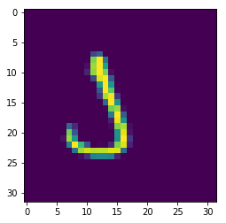

```
This image predicted as letter  zaa  =  ظ
But sorry that is wrong
```

[8 more figures not shown]

```
This image predicted as letter  yaa  =  ي
And that is right
```

```python
random_imgs = np.random.randint(x_test.shape[0], size = 20)
for i in random_imgs:
    img = x_test_reshape[i]
    # show image
    plt.imshow(img.squeeze().T)
    plt.show()
    img = img.reshape(1, 32, 32)
    pred_matrix = cnn_model.predict(img)
    pred = np.argmax(pred_matrix)
    #print(pred)
    #print(pred_matrix)
    print ("This image predicted as letter ", arabic_labels[pred], ' = ', arabic_letters[pred])
    # Check if predicted label equal to the True label
    if pred+1 == y_test[i]:
        print("And that is right")
    else:
        print("But sorry that is wrong")
```

# Conclusion:

- As a result of the training for a different classifiers, we found that the CNN model shows the best accuracy with 86.0714%, so the model passed the benchmark metric.
- The Deep Learning Convolution Neural Networks are very promised in Computer Vision and Handwritten Arabic OCR fields, Also Support Vector Machines algorithm can used in this fields as a cheaper solution with reasonable accuracy, the CNN model can be improved using the power of GPUs by using augmentation, randomization and transfer learning.